# 小组模拟实验代码

### 以下是我们小组对论文部分模型的代码复现：

### 我们比较了ACH(1,1) model与其相对于benchmark model在固定参数及对参数alpha、beta(代码中设为a,b)网格搜索时的性能。(比较标准：相同参数下的对数似然函数值)

### 在具体操作时，我们对数据和模型做了以下简化:

#### ①从basics.mat文件读取源数据，观察各外生变量的大致分布，在以下试验中据我们所观测分布随机生成一定范围的负载、温度数据(我们将外生变量凝结成了两大类：负载和温度，所以外生变量的向量z=[1,z1,z2]

#### ②我们将下图的lamda设置为1（这其实并不科学。但此处是我们模拟实验的一个瓶颈，我们没有理解作者是如何调整lambda值的。如有机会，我们很有意愿email原作者这个小问题。）

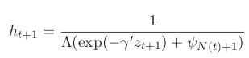

```python
#ACH(1,1),lambda=1
import numpy as np
def fai(v,a,b,dPrevious,faiPrevious):
    return (a*dPrevious**v+b*faiPrevious**v)**(1/v)
def h(gamma0,gamma1,gamma2,z1,z2,fai):
    import math
    import numpy as np
    tmp=gamma0+gamma1*z1+gamma2*z2
    fenmu=math.exp(-tmp)+fai
    return 1.0/fenmu
def ACHlogfunc(gamma0,gamma1,gamma2,load,temp,v,a,b,delta,spikeCondition):
    faiList=[5]*1440
    hdata=h(gamma0,gamma1,gamma2,load[0],temp[0],faiList[0])
    hlist=[hdata]
    logvalue=(1-spikeCondition[0])*(1-hdata)+(spikeCondition[0])*(hdata)
    for i in range(1,len(spikeCondition)):
        faiList[i]=(a*(delta[i-1])**v+b*(faiList[i-1])**v)**(1/v)
        hdata=h(gamma0,gamma1,gamma2,load[i],temp[i],faiList[i])
        hlist.append(hdata)
        tmp=(1-spikeCondition[i])*np.log(1-hdata)+spikeCondition[i]*np.log(hdata)
        logvalue+=tmp
    return logvalue,hlist
def benchmarklogfunc(gamma0,gamma1,gamma2,load,temp,v,a,b,delta,spikeCondition):
    faiList=[1]*1440
    hdata=h(gamma0,gamma1,gamma2,load[0],temp[0],faiList[0])
    hlist=[hdata]
    logvalue=(1-spikeCondition[0])*(1-hdata)+(spikeCondition[0])*(hdata)
    for i in range(1,len(spikeCondition)):
        hdata=h(gamma0,gamma1,gamma2,load[i],temp[i],faiList[i])
        hlist.append(hdata)
        tmp=(1-spikeCondition[i])*np.log(1-hdata)+spikeCondition[i]*np.log(hdata)
        logvalue+=tmp
    return logvalue,hlist
```

### 生成一个月数据用来模拟(30*48=1440),48表示每天隔半个小时取一次样本，共取48次

```python
#生成极端电价(随机生成[0,10]区间的整数，设定规则：>=8为极端事件发生(spikeCondition=1)，否则未发生(spikeCondition=0))
#这样保证极端事件发生概率将较小
import random

spikeCondition=[]
for i in range(1440):
    spikeCondition.append(int(random.randint(0,10)>=8))

#生成温度数据（观察basic.mat实际数据的大体分布后，决定如下模拟）
temp=[]
for i in range(1440):
    temp.append(random.randrange(10,40))

#生成负载数据（观察basic.mat实际数据的大体分布后，决定如下模拟）
load=[]
for i in range(1440):
    load.append(random.randrange(1000,10000))

#将负载和温度数据归一化
max_min_scaler = lambda x : (x-np.min(x))/(np.max(x)-np.min(x))
temp=max_min_scaler(temp)
load=max_min_scaler(load)
```

```python
#根据以上数据求出极端事件发生时间间隔数列delta

#计算发生极端事件的时间点
spikeindex=[]
for i in range(1440):
    if spikeCondition[i]==1:
        spikeindex.append(i)
#计算时间间隔
tmp=[spikeindex[0]]
for i in range(len(spikeindex)-1):
    tmp.append(spikeindex[i+1]-spikeindex[i])
#构造时间间隔序列
delta=[0]*spikeindex[0]
for i in range(len(tmp)):
    if i!=(len(tmp)-1):
        for j in range(tmp[i+1]):
            delta.append(tmp[i])
    else:
        for j in range(tmp[i]):
            delta.append(tmp[i])
if len(delta)<1440:
    end=delta[-1]
    for i in range(1440-len(delta)):
        delta.append(end)
```

```python
print(spikeCondition)
```

```
[0, 0, 1, 0, 0, 1, 1, 0, 0, 0, 1, 1, 0, 0, 0, 1, 0, 0, 0, 0, 0, 1, 0, 0, 1, 1, 0, 0, 0, 1, 0, 1, 0, 1, 0, 0, 1, 0, 0, 1, 0, 1, 1, 1, 0, 0, 0, 1, 0, 0, 0, 1, 1, 0, 0, 0, 0, 1, 1, 0, 0, 1, 0, 0, 0, 1, 0, 0, 1, 1, 0, 1, 0, 0, 0, 0, 0, 1, 0, 0, 0, 1, 0, 0, 1, 0, 0, 0, 1, 0, 0, 0, 0, 0, 0, 1, 0, 1, 0, 1,…
```

```python
print(delta)
```

```
[0, 0, 2, 2, 2, 3, 1, 1, 1, 1, 4, 1, 1, 1, 1, 4, 4, 4, 4, 4, 4, 6, 6, 6, 3, 1, 1, 1, 1, 4, 4, 2, 2, 2, 2, 2, 3, 3, 3, 3, 3, 2, 1, 1, 1, 1, 1, 4, 4, 4, 4, 4, 1, 1, 1, 1, 1, 5, 1, 1, 1, 3, 3, 3, 3, 4, 4, 4, 3, 1, 1, 2, 2, 2, 2, 2, 2, 6, 6, 6, 6, 4, 4, 4, 3, 3, 3, 3, 4, 4, 4, 4, 4, 4, 4, 7, 7, 2, 2, 2,…
```

```python
#给定参数下,ACH(1,1)、benchmark model的对数似然函数值
ACHlogfunc(0.1,0.7,-0.2,load,temp,1.0,0.5,0.4,delta,spikeCondition)[0],benchmarklogfunc(0.1,0.7,-0.2,load,temp,1.0,0.5,0.4,delta,spikeCondition)[0]
```

```
(-904.9864927114387, -1150.1095604437858)
```

```python
#对a,b进行网格搜索时,ACH(1,1)、benchmark model的对数似然函数值
for a in np.arange(0.1,0.9,0.1):
    for b in np.arange(0.1,1-a,0.1):
        print('a=',a,'b=',b)
        print(ACHlogfunc(0.1,0.7,-0.2,load,temp,1.0,a,b,delta,spikeCondition)[0],benchmarklogfunc(0.1,0.7,-0.2,load,temp,1.0,a,b,delta,spikeCondition)[0])
```

```
a= 0.1 b= 0.1
nan -1150.1095604437858
a= 0.1 b= 0.2
nan -1150.1095604437858
a= 0.1 b= 0.30000000000000004
nan -1150.1095604437858
a= 0.1 b= 0.4
nan -1150.1095604437858
a= 0.1 b= 0.5
nan -1150.1095604437858
a= 0.1 b= 0.6
nan -1150.1095604437858
a= 0.1 b= 0.7000000000000001
nan -1150.1095604437858
a= 0.1 b= 0.8
-946.8527856188006 -1150.1095604437858
a= 0.2 b= 0.1
```

```
nan -1150.1095604437858
a= 0.2 b= 0.2
nan -1150.1095604437858
a= 0.2 b= 0.30000000000000004
nan -1150.1095604437858
a= 0.2 b= 0.4
nan -1150.1095604437858
a= 0.2 b= 0.5
nan -1150.1095604437858
a= 0.2 b= 0.6
-1012.4565006404716 -1150.1095604437858
a= 0.2 b= 0.7000000000000001
-898.4455336079715 -1150.1095604437858
a= 0.30000000000000004 b= 0.1
nan -1150.1095604437858
a= 0.30000000000000004 b= 0.2
nan -1150.1095604437858
a= 0.30000000000000004 b= 0.30000000000000004
nan -1150.1095604437858
a= 0.30000000000000004 b= 0.4
nan -1150.1095604437858
a= 0.30000000000000004 b= 0.5
-966.1028909798243 -1150.1095604437858
a= 0.30000000000000004 b= 0.6
-895.0202319855553 -1150.1095604437858
a= 0.4 b= 0.1
nan -1150.1095604437858
a= 0.4 b= 0.2
nan -1150.1095604437858
a= 0.4 b= 0.30000000000000004
-1028.2082841239371 -1150.1095604437858
a= 0.4 b= 0.4
-952.0137747309424 -1150.1095604437858
a= 0.4 b= 0.5
-899.2366776873419 -1150.1095604437858
a= 0.5 b= 0.1
nan -1150.1095604437858
a= 0.5 b= 0.2
nan -1150.1095604437858
a= 0.5 b= 0.30000000000000004
-947.3653196828959 -1150.1095604437858
a= 0.5 b= 0.4
-904.9864927114387 -1150.1095604437858
a= 0.6 b= 0.1
nan -1150.1095604437858
a= 0.6 b= 0.2
nan -1150.1095604437858
a= 0.6 b= 0.30000000000000004
-910.6280193799787 -1150.1095604437858
a= 0.6 b= 0.4
-886.6420030223182 -1150.1095604437858
a= 0.7000000000000001 b= 0.1
nan -1150.1095604437858
a= 0.7000000000000001 b= 0.2
nan -1150.1095604437858
a= 0.8 b= 0.1
nan -1150.1095604437858
```

#### 以上实验中，当ACH(1,1)的对数似然函数不为nan时，其对数似然函数值皆大于对应的benchmark model值

#### 由于不知如何对表达式中的lambda归一化(论文中一笔带过了)，ACH(1,1)的对数似然函数会时不时出现nan值，这也是我们实现模型时遇到的瓶颈。如果有机会，我们很有意愿email原作者这个小问题。

```python
hOfACH=ACHlogfunc(0.1,0.7,-0.2,load,temp,1.0,0.5,0.4,delta,spikeCondition)[1]
hOfbench=benchmarklogfunc(0.1,0.7,-0.2,load,temp,1.0,0.5,0.4,delta,spikeCondition)[1]
```

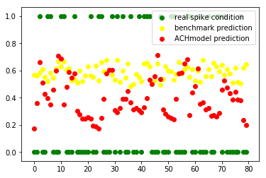

```python
#抽取1440个样本中前80个进行绘图，比较ACH与基准模型预测的h和真实结果的差异
import matplotlib.pyplot as plt
x=list(range(80))
plt.scatter(x,spikeCondition[:80],color='green',label='real spike condition')
plt.scatter(x,hOfbench[:80],color='yellow',label='benchmark prediction')
plt.scatter(x,hOfACH[:80],color='red',label='ACHmodel prediction')
plt.legend()
plt.show()
```

#### 由于我们的实验将论文模型进行了简化，数据是依照分布按一定规律随机生成的（并非真实数据）（且只考虑的一个月的情况，从而为考虑季节对负载、温度变化的影响），h表达式中lambda归一化问题也未解决，模型结果不甚理想也是意料之中。

#### 不过，从上图我们还是可以观察出一些迹象：benchmark model预测的h值几乎都在一条水平线附近波动，并无区分性，其预测效果也就存疑。而ACH model预测效果虽也欠佳，却在相对高点时和真实极端电价事件的发生恰好吻合，这一点比基准模型更具预测性能上的说服力。